# Survival Analysis

The core survival analysis functions are in the `survival` package. We will also want to load the `survminer` package, which provides much nicer Kaplan-Meier plots out-of-the-box than what you get out of base graphics.

```r
library(dplyr)
library(survival)
library(survminer)
```

The core functions we are going to use out of the `survival` package include:

- `Surv()`: Creates a survival object. Creates the response variable, and typical usage takes the time to event, and whether or not the event occurred (i.e., death vs censored).
- `survfit()`: Fits a survival curve using either a formula, of from a previously fitted Cox model. Creates a survival curve that you could then display or plot.
- `coxph()`: Fits a Cox proportional hazards regression model. It implements the regression analysis, and models specified the same way as in regular linear models, but using the `coxph()` function.
- `survdiff()`: Tests for differences in survival between two groups using a log-rank / Mantel-Haenszel test.

# 1 Lung Data

We are going to be using the built-in lung cancer dataset that ships with the survival package. You can get some more information about the dataset by running `?lung`. The help tells us there are 10 variables in this data:

```r
library(survival)
# ?lung
```

1. inst: Institution code
2. time: Survival time in days
3. status: censoring status 1=censored, 2=dead
4. age: Age in years
5. sex: Male=1 Female=2
6. ph.ecog: ECOG performance score (0=good 5=dead)
7. ph.karno: Karnofsky performance score as rated by physician
8. pat.karno: Karnofsky performance score as rated by patient
9. meal.cal: Calories consumed at meals
10. wt.loss: Weight loss in last six months

```r
head(lung)
```

```
##   inst time status age sex ph.ecog ph.karno pat.karno meal.cal wt.loss
## 1    3  306      2  74   1       1       90       100     1175      NA
## 2    3  455      2  68   1       0       90        90     1225      15
## 3    3 1010      1  56   1       0       90        90       NA      15
## 4    5  210      2  57   1       1       90        60     1150      11
## 5    1  883      2  60   1       0      100        90       NA       0
## 6   12 1022      1  74   1       1       50        80      513       0
```

```r
class(lung)
```

```
## [1] "data.frame"
```

```r
dim(lung)
```

```
## [1] 228  10
```

# 2 Survival Curves

Check out the help for `?Surv`. This is the main function we will use to create the survival object.

Try creating a survival object called `s`, then display it. If you go back and `head(lung)` the data, you can see how these are related. It’s a special type of vector that tells you both how long the subject was tracked for, and whether or not the event occured or the sample was censored (shown by the `+`).

```r
s <- Surv(lung$time, lung$status)
class(s)
```

```
## [1] "Surv"
```

```r
head(s)
```

```
## [1]  306   455  1010+  210   883  1022+
```

```r
head(lung)
```

```
##   inst time status age sex ph.ecog ph.karno pat.karno meal.cal wt.loss
## 1    3  306      2  74   1       1       90       100     1175      NA
## 2    3  455      2  68   1       0       90        90     1225      15
## 3    3 1010      1  56   1       0       90        90       NA      15
## 4    5  210      2  57   1       1       90        60     1150      11
## 5    1  883      2  60   1       0      100        90       NA       0
## 6   12 1022      1  74   1       1       50        80      513       0
```

Now, let’s fit a survival curve with the `survfit()` function. First we will create a simple survival curve that doesn’t consider any different groupings, so we’ll specify just an intercept (e.g., `~1`) in the formula that `survfit` expects.

```r
# s <- Surv(lung$time, lung$status)
# sfit <- survfit(s~1)
sfit <- survfit(Surv(time, status)~1, data=lung)
# summary(sfit)
```

You can give the `summary()` function an option for what times you want to show in the results. Look at the range of followup times in the lung dataset with `range()`. You can create a sequence of numbers going from one number to another number by increments of yet another number with the `seq()` function.

```r
range(lung$time)
```

```
## [1]    5 1022
```

```r
seq(0, 1100, 100)
```

```
##  [1]    0  100  200  300  400  500  600  700  800  900 1000 1100
```

And we can use that sequence vector with a summary call on `sfit` to get life tables at those intervals we are interested in.

```r
summary(sfit, times=seq(0, 1000, 100))
```

```
## Call: survfit(formula = Surv(time, status) ~ 1, data = lung)
##
##  time n.risk n.event survival std.err lower 95% CI upper 95% CI
##     0    228       0   1.0000  0.0000       1.0000        1.000
##   100    196      31   0.8640  0.0227       0.8206        0.910
##   200    144      41   0.6803  0.0311       0.6219        0.744
##   300     92      29   0.5306  0.0346       0.4669        0.603
##   400     57      25   0.3768  0.0358       0.3128        0.454
##   500     41      12   0.2933  0.0351       0.2320        0.371
##   600     24      10   0.2136  0.0335       0.1571        0.290
##   700     16       8   0.1424  0.0303       0.0938        0.216
##   800      8       7   0.0783  0.0246       0.0423        0.145
##   900      3       2   0.0503  0.0228       0.0207        0.123
##  1000      2       0   0.0503  0.0228       0.0207        0.123
```

Let’s fit survival curves separately by sex.

```r
sfit <- survfit(Surv(time, status)~sex, data=lung)
summary(sfit,times=seq(0, 1000, 100))
```

```
## Call: survfit(formula = Surv(time, status) ~ sex, data = lung)
##
##                 sex=1
##  time n.risk n.event survival std.err lower 95% CI upper 95% CI
##     0    138       0   1.0000  0.0000       1.0000        1.000
##   100    114      24   0.8261  0.0323       0.7652        0.892
##   200     78      30   0.6073  0.0417       0.5309        0.695
##   300     49      20   0.4411  0.0439       0.3629        0.536
##   400     31      15   0.2977  0.0425       0.2250        0.394
##   500     20       7   0.2232  0.0402       0.1569        0.318
##   600     13       7   0.1451  0.0353       0.0900        0.234
##   700      8       5   0.0893  0.0293       0.0470        0.170
##   800      6       2   0.0670  0.0259       0.0314        0.143
##   900      2       2   0.0357  0.0216       0.0109        0.117
##  1000      2       0   0.0357  0.0216       0.0109        0.117
##
##                 sex=2
##  time n.risk n.event survival std.err lower 95% CI upper 95% CI
##     0     90       0   1.0000  0.0000       1.0000        1.000
##   100     82       7   0.9221  0.0283       0.8683        0.979
##   200     66      11   0.7946  0.0432       0.7142        0.884
##   300     43       9   0.6742  0.0523       0.5791        0.785
##   400     26      10   0.5089  0.0603       0.4035        0.642
##   500     21       5   0.4110  0.0626       0.3050        0.554
##   600     11       3   0.3433  0.0634       0.2390        0.493
##   700      8       3   0.2496  0.0652       0.1496        0.417
##   800      2       5   0.0832  0.0499       0.0257        0.270
##   900      1       0   0.0832  0.0499       0.0257        0.270
```

Now that we’ve fit a survival curve to the data it’s pretty easy to visualize it with a **Kaplan-Meier** plot.

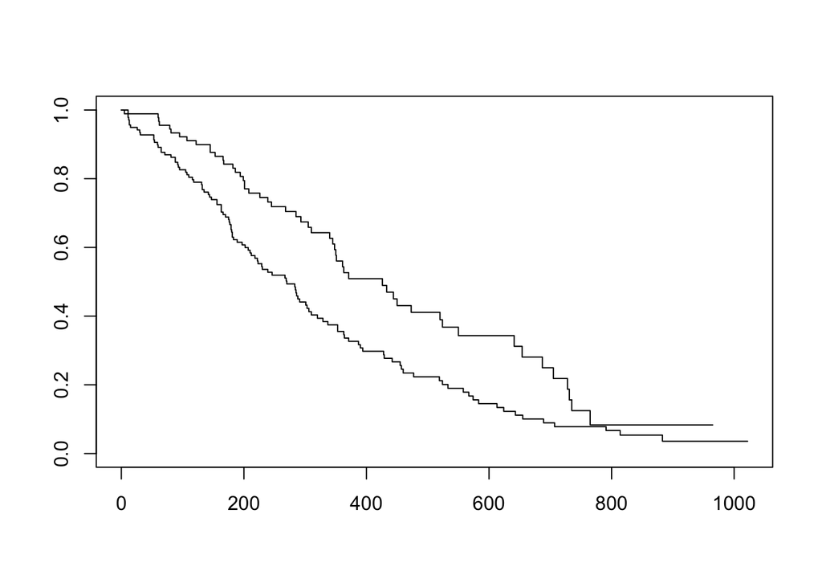

```r
plot(sfit)
```

There’s another package called `survminer` that provides a function called `ggsurvplot()` that makes it much easier to produce publication-ready survival plots. So, let’s load the package and try it out.

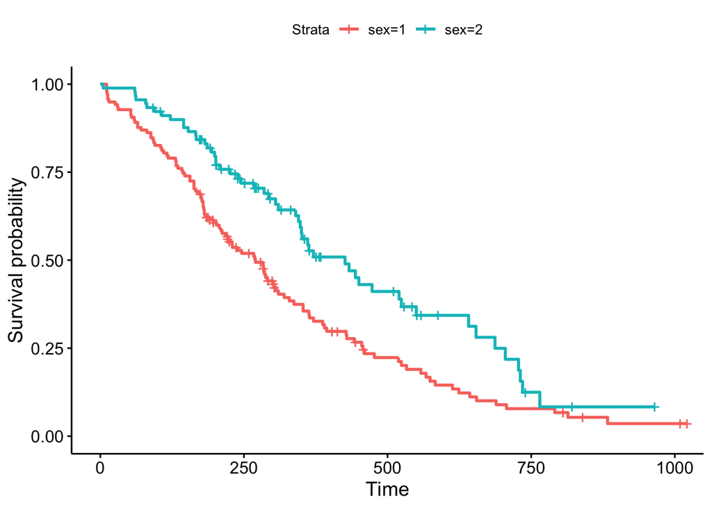

```r
library(survminer)
ggsurvplot(sfit)
```

This plot is substantially more informative by default, just because it automatically color codes the different groups, adds axis labels, and creates and automatic legend. But there’s a lot more you can do pretty easily here. Let’s add confidence intervals, show the p-value for the log-rank test, show a risk table below the plot, and change the colors and the group labels.

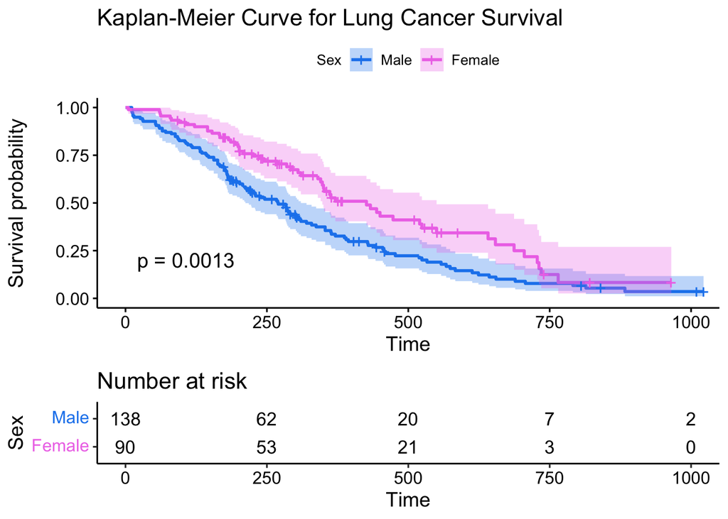

```r
ggsurvplot(
  sfit,
  conf.int = TRUE,
  pval = TRUE,
  risk.table = TRUE,
  legend.labs = c("Male", "Female"),
  legend.title = "Sex",
  palette = c("dodgerblue2", "orchid2"),
  title = "Kaplan-Meier Curve for Lung Cancer Survival",
  risk.table.height = .3
)
```

# 3 Cox Regression

Kaplan-Meier curves are good for visualizing differences in survival between two categorical groups, and the log-rank test you get when you ask for `pval=TRUE` is useful for asking if there are differences in survival between different groups. But this doesn’t generalize well for assessing the effect of **quantitative variables**.

Let’s go back to the lung cancer data and run a Cox regression on sex.

```r
fit <- coxph(Surv(time, status)~sex, data=lung)
fit
```

```
## Call:
## coxph(formula = Surv(time, status) ~ sex, data = lung)
##
##        coef exp(coef) se(coef)      z       p
## sex -0.5310    0.5880   0.1672 -3.176 0.00149
##
## Likelihood ratio test=10.63  on 1 df, p=0.001111
## n= 228, number of events= 165
```

Hazard Ratio: `exp(coef)`

- HR=1: No effect
- HR>1: Increase in hazard
- HR<1: Reduction in hazard (protective)

You’ll also notice there’s a p-value on the `sex` term, and a p-value on the overall model. That 0.00111 p-value is really close to the 0.00131 p-value we saw on the Kaplan-Meier plot. That’s because the KM plot is showing the log-rank test p-value. You can get this out of the Cox model with a call to `summary(fit)`. You can directly calculate the log-rank test p-value using `survdiff()`.

```r
summary(fit)
```

```
## Call:
## coxph(formula = Surv(time, status) ~ sex, data = lung)
##
##   n= 228, number of events= 165
##
##        coef exp(coef) se(coef)      z Pr(>|z|)
## sex -0.5310    0.5880   0.1672 -3.176  0.00149 **
## ---
## Signif. codes:  0 '***' 0.001 '**' 0.01 '*' 0.05 '.' 0.1 ' ' 1
##
##     exp(coef) exp(-coef) lower .95 upper .95
## sex     0.588      1.701    0.4237     0.816
##
## Concordance= 0.579  (se = 0.021 )
## Likelihood ratio test= 10.63  on 1 df,   p=0.001
## Wald test            = 10.09  on 1 df,   p=0.001
## Score (logrank) test = 10.33  on 1 df,   p=0.001
```

```r
survdiff(Surv(time, status)~sex, data=lung)
```

```
## Call:
## survdiff(formula = Surv(time, status) ~ sex, data = lung)
##
##         N Observed Expected (O-E)^2/E (O-E)^2/V
## sex=1 138      112     91.6      4.55      10.3
## sex=2  90       53     73.4      5.68      10.3
##
##  Chisq= 10.3  on 1 degrees of freedom, p= 0.001
```

The Cox regression results can be interpreted as follow:

1.** Statistical significance**. The column marked “z” gives the Wald statistic value. It corresponds to the ratio of each regression coefficient to its standard error (z = coef/se(coef)). The wald statistic evaluates, whether the beta coefficient of a given variable is statistically significantly different from 0. From the output above, we can conclude that the variable sex have highly statistically significant coefficients.

2. **The regression coefficients**. The second feature to note in the Cox model results is the the sign of the regression coefficients (coef). A positive sign means that the hazard (risk of death) is higher, and thus the prognosis worse, for subjects with higher values of that variable. The variable sex is encoded as a numeric vector. 1: male, 2: female. The R summary for the Cox model gives the hazard ratio (HR) for the second group relative to the first group, that is, female versus male. The beta coefficient for sex = -0.53 indicates that females have lower risk of death (higher survival rates) than males, in these data.
3. **Hazard ratios**. The exponentiated coefficients (exp(coef) = exp(-0.53) = 0.59), also known as hazard ratios, give the effect size of covariates. For example, being female (sex=2) reduces the hazard by a factor of 0.59. Being female is associated with good prognostic.
4. **Confidence intervals of the hazard ratios**. The summary output also gives upper and lower 95% confidence intervals for the hazard ratio (exp(coef)), lower 95% bound = 0.4237, upper 95% bound = 0.816.
5. **Global statistical significance of the model**. Finally, the output gives p-values for three alternative tests for overall significance of the model: The likelihood-ratio test, Wald test, and score logrank statistics. These three methods are asymptotically equivalent. For large enough N, they will give similar results. For small N, they may differ somewhat. The Likelihood ratio test has better behavior for small sample sizes, so it is generally preferred.

Let’s create another model where we analyze all the variables in the dataset! This shows us how all the variables, when considered together, act to influence survival.

```r
fit.all <- coxph(Surv(time,status)~sex+age+ph.ecog+ph.karno+pat.karno+meal.cal+wt.loss, data=lung)
fit.all
```

```
## Call:
## coxph(formula = Surv(time, status) ~ sex + age + ph.ecog + ph.karno +
##     pat.karno + meal.cal + wt.loss, data = lung)
##
##                 coef  exp(coef)   se(coef)      z       p
## sex       -5.509e-01  5.765e-01  2.008e-01 -2.743 0.00609
## age        1.065e-02  1.011e+00  1.161e-02  0.917 0.35906
## ph.ecog    7.342e-01  2.084e+00  2.233e-01  3.288 0.00101
## ph.karno   2.246e-02  1.023e+00  1.124e-02  1.998 0.04574
## pat.karno -1.242e-02  9.877e-01  8.054e-03 -1.542 0.12316
## meal.cal   3.329e-05  1.000e+00  2.595e-04  0.128 0.89791
## wt.loss   -1.433e-02  9.858e-01  7.771e-03 -1.844 0.06518
##
## Likelihood ratio test=28.33  on 7 df, p=0.0001918
## n= 168, number of events= 121
##    (60 observations deleted due to missingness)
```

- Some are very strong predictors (sex, ECOG score).
- Interestingly, the Karnofsky performance score as rated by the physician was marginally significant, while the same score as rated by the patient was not.